# This is a short introduction to pandas!

Customarily, we import as follows:

```python
# In python, when using functions from packages, you will need to address where the function is coming from. You can see, when importing a package we give it an alias ('pd', 'np'). You can do this for any imported package you want.

import numpy as np # Numpy works hand-in-hand with pandas often. It's a very large package with a ton of functionality. No need to try and learn all of it at once. You'll pick up on things as you need them
import pandas as pd
```

### Introduction to Data Structures

Pandas uses two primary components. These are **Series** and **DataFrames**. A series is essentially a column, and a DataFrame is a multi-dimensional table made of a collection of Series. DataFrames and Series are quite similar in that many operations that you can do with one you can do with the other, such as filling in null values and calculating the mean.

### Series

**Series** is a one-dimensional labeled array capable of holding any data type (integers, strings, floating point numbers, Python objects, etc.). The axis labels are collectively referred to as the index. The basic method to create a Series is to call:

```python
data = [1, 2, 3, 4] # test list
index = [0, 1, 2 ,3 ] # most pandas objects will naturaly have indicies starting at 0, incrementing by 1 per row
```

```python
s = pd.Series(data, index=index)
s
```

```
0    1
1    2
2    3
3    4
dtype: int64
```

### DataFrames

Creating **DataFrames** right in Python is good to know and quite useful when testing new methods and functions you find in the pandas docs.

There are many ways to create a DataFrame from scratch, but a great option is to just use a simple dict.

Let's say we have a fruit stand that sells apples and oranges. We want to have a column for each fruit and a row for each customer purchase. To organize this as a dictionary for pandas we could do something like:

```python
data = {  # dict key = column, dict value = list of values, aka our rows for the df
    'apples': [3, 2, 0, 1],
    'oranges': [0, 3, 7, 2]
}
```

```python
purchases = pd.DataFrame(data)

purchases
```

|  | apples | oranges |
| --- | --- | --- |
| 0 | 3 | 0 |
| 1 | 2 | 3 |
| 2 | 0 | 7 |
| 3 | 1 | 2 |

You may be asking, how did pandas know how to do that? Well, each (key, value) item in data corresponds to a column in the resulting DataFrame.

The Index of this DataFrame was given to us on creation as the numbers 0-3, but we could also create our own when we initialize the DataFrame.

```python
# We could set a custom index like so...
purchases = pd.DataFrame(data, index=['June', 'Robert', 'Lily', 'David'])

purchases
```

|  | apples | oranges |
| --- | --- | --- |
| June | 3 | 0 |
| Robert | 2 | 3 |
| Lily | 0 | 7 |
| David | 1 | 2 |

In order to select a specific row, we will need to select the correct index. Since we have customer names as the index, it will look something like this...

```python
purchases.loc['June']
```

```
apples     3
oranges    0
Name: June, dtype: int64
```

### Reading data from CSVs

```python
# If you run the cell below and get an error it is becausee you do not have pydataset downloaded. Run the code below to gather it.
!pip install pydataset
```

```python
from pydataset import data
```

```python
# Shows all the possible datasets pydataset has to use
data()
```

|  | dataset_id | title |
| --- | --- | --- |
| 0 | AirPassengers | Monthly Airline Passenger Numbers 1949-1960 |
| 1 | BJsales | Sales Data with Leading Indicator |
| 2 | BOD | Biochemical Oxygen Demand |
| 3 | Formaldehyde | Determination of Formaldehyde |
| 4 | HairEyeColor | Hair and Eye Color of Statistics Students |
| ... | ... | ... |
| 752 | VerbAgg | Verbal Aggression item responses |
| 753 | cake | Breakage Angle of Chocolate Cakes |
| 754 | cbpp | Contagious bovine pleuropneumonia |
| 755 | grouseticks | Data on red grouse ticks from Elston et al. 2001 |
| 756 | sleepstudy | Reaction times in a sleep deprivation study |

757 rows × 2 columns

```python
# Let's use the standard iris data set
iris_df = data('iris')
```

Now that we have a data set, let's write it to a **.csv** file, and then read it back in

```python
iris_df.to_csv('iris.csv', index=False)
```

```python
iris_df = pd.read_csv('iris.csv')
# we can take a peek at the top rows by calling .head(). You can pass any number of rows into the function. By default, it is 5
display(iris_df.head()) # it is worth noting, in order to see a nicely formatted print of a df, you will need to call display() to print out a dataframe

# print(iris_df) # print gives an ugly return. Uncomment it if you want to see

# or we can take a look at the .tail(). Also default of 5 rows
display(iris_df.tail())
```

|  | Sepal.Length | Sepal.Width | Petal.Length | Petal.Width | Species |
| --- | --- | --- | --- | --- | --- |
| 0 | 5.1 | 3.5 | 1.4 | 0.2 | setosa |
| 1 | 4.9 | 3.0 | 1.4 | 0.2 | setosa |
| 2 | 4.7 | 3.2 | 1.3 | 0.2 | setosa |
| 3 | 4.6 | 3.1 | 1.5 | 0.2 | setosa |
| 4 | 5.0 | 3.6 | 1.4 | 0.2 | setosa |

|  | Sepal.Length | Sepal.Width | Petal.Length | Petal.Width | Species |
| --- | --- | --- | --- | --- | --- |
| 145 | 6.7 | 3.0 | 5.2 | 2.3 | virginica |
| 146 | 6.3 | 2.5 | 5.0 | 1.9 | virginica |
| 147 | 6.5 | 3.0 | 5.2 | 2.0 | virginica |
| 148 | 6.2 | 3.4 | 5.4 | 2.3 | virginica |
| 149 | 5.9 | 3.0 | 5.1 | 1.8 | virginica |

```python
# Let's take a look at some info about our df
iris_df.info()

# When looking at the types of data stored in columns of a df, 'type()' won't do the job. We will need to use dtype()

print(iris_df['Sepal.Length'].dtype) # dtype('float64')
```

```
<class 'pandas.core.frame.DataFrame'>
RangeIndex: 150 entries, 0 to 149
Data columns (total 5 columns):
 #   Column        Non-Null Count  Dtype
---  ------        --------------  -----
 0   Sepal.Length  150 non-null    float64
 1   Sepal.Width   150 non-null    float64
 2   Petal.Length  150 non-null    float64
 3   Petal.Width   150 non-null    float64
 4   Species       150 non-null    object
dtypes: float64(4), object(1)
memory usage: 6.0+ KB
float64
```

```python
iris_df.shape # number of rows, number of columns
```

```
(150, 5)
```

```python
# Let's see how we would deal with duplicate data. First I will make a temp_df that will have iris_df built upon itself

temp_df = iris_df.append(iris_df)
temp_df.shape # 300 , 5. We now have duplicate data
```

```
(300, 5)
```

```python
temp_df = temp_df.drop_duplicates()

temp_df.shape # we naturally had one row in the original iris_df that had a duplicate, but as you can see we removed the duplicate data. This needs to be done with caution is data science, as you can accidentally remove data
```

```
(149, 5)
```

```python
# What if we want to rename these columns? I don't like how the words are concatenated with a '.'. Let's change that.

# peek at all the columns
print(iris_df.columns)

iris_df.rename(columns={
        'Sepal.Length': 'Sepal Length',
        'Sepal.Width': 'Sepal Width',
        'Petal.Length' : 'Petal Length',
        'Petal.Width' : 'Petal Width'
    }, inplace=True)  # calling 'inplace' here allows me to save this to the df without having to reassign the variable like:  df = ...

display(iris_df.head())
```

```
Index(['Sepal.Length', 'Sepal.Width', 'Petal.Length', 'Petal.Width',
       'Species'],
      dtype='object')
```

|  | Sepal Length | Sepal Width | Petal Length | Petal Width | Species |
| --- | --- | --- | --- | --- | --- |
| 0 | 5.1 | 3.5 | 1.4 | 0.2 | setosa |
| 1 | 4.9 | 3.0 | 1.4 | 0.2 | setosa |
| 2 | 4.7 | 3.2 | 1.3 | 0.2 | setosa |
| 3 | 4.6 | 3.1 | 1.5 | 0.2 | setosa |
| 4 | 5.0 | 3.6 | 1.4 | 0.2 | setosa |

We can do some boolean indexing on conditions as well to subset our data

```python
# Let's look for a 'Sepal Length' with values greater than 5.0
iris_df[iris_df['Sepal Length'] > 5.0].head()

# It's also good practice to consider copying your dfs when doing exploratory manipluation so you dont mutate your original df. You can achieve this by calling:
iris_copy = iris_df.copy()

# Now we have a copy of our original df that we can use to do whatever we want without losing the original state of our 'master'
```

There's so much more pandas functionality you can get into, but soon it becomes a case of finding things when you need them. You'll naturally retain these methods over time as you use them, and extraneous methods will come up as you google and implement them. Let's move onto just some simple plots you can make within the pandas space. There are many plotting packages in python, but pandas uses 'matplotlib' that can allow you to make some quick and simple plots without having to import a specifc plotting package.

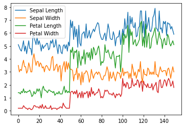

```python
# This is as basic as basic gets. Simple line plot on the entire df (default).

iris_df.plot()
```

```
array([[<AxesSubplot:title={'center':'Sepal Length'}>,
        <AxesSubplot:title={'center':'Sepal Width'}>],
       [<AxesSubplot:title={'center':'Petal Length'}>,
        <AxesSubplot:title={'center':'Petal Width'}>]], dtype=object)
```

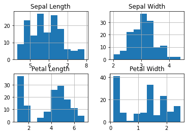

```python
# Simple historgrams of each column
iris_df.hist()
```

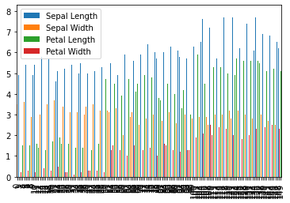

```python
# Ugly but worth noting you can pass the param 'kind' to the standard plot function to get a type of plot like 'bar'
iris_df.plot(kind="bar")
```

## Joins

The last thing I will cover is somewhat basic on the surface level, but you'll find with data that this can become challenging. Let's discuss joining datasets together. There are mainly three different types of joins you will come across. These are: inner, outer, left/right.

[figure not shown]

```python
product=pd.DataFrame({
    'Product_ID':[101,102,103,104,105,106,107],
    'Product_name':['Watch','Bag','Shoes','Smartphone','Books','Oil','Laptop'],
    'Category':['Fashion','Fashion','Fashion','Electronics','Study','Grocery','Electronics'],
    'Price':[299.0,1350.50,2999.0,14999.0,145.0,110.0,79999.0],
    'Seller_City':['Delhi','Mumbai','Chennai','Kolkata','Delhi','Chennai','Bengalore']
})
```

```python
customer=pd.DataFrame({
    'id':[1,2,3,4,5,6,7,8,9],
    'name':['Olivia','Aditya','Cory','Isabell','Dominic','Tyler','Samuel','Daniel','Jeremy'],
    'age':[20,25,15,10,30,65,35,18,23],
    'Product_ID':[101,0,106,0,103,104,0,0,107],
    'Purchased_Product':['Watch','NA','Oil','NA','Shoes','Smartphone','NA','NA','Laptop'],
    'City':['Mumbai','Delhi','Bangalore','Chennai','Chennai','Delhi','Kolkata','Delhi','Mumbai']
})
```

```python
# Here we are taking the two dfs above, identifying a like column (ID) and joining 'inner' aka like data (same ID between the two)

pd.merge(product, customer, on='Product_ID', how='inner')
```

|  | Product_ID | Product_name | Category | Price | Seller_City | id | name | age | Purchased_Product | City |
| --- | --- | --- | --- | --- | --- | --- | --- | --- | --- | --- |
| 0 | 101 | Watch | Fashion | 299.0 | Delhi | 1 | Olivia | 20 | Watch | Mumbai |
| 1 | 103 | Shoes | Fashion | 2999.0 | Chennai | 5 | Dominic | 30 | Shoes | Chennai |
| 2 | 104 | Smartphone | Electronics | 14999.0 | Kolkata | 6 | Tyler | 65 | Smartphone | Delhi |
| 3 | 106 | Oil | Grocery | 110.0 | Chennai | 3 | Cory | 15 | Oil | Bangalore |
| 4 | 107 | Laptop | Electronics | 79999.0 | Bengalore | 9 | Jeremy | 23 | Laptop | Mumbai |

```python
# If the column names were different but we still wanted to join them on a like column, we'd have to explicitly call the columns
pd.merge(product,customer,left_on='Product_name',right_on='Purchased_Product')
```

|  | Product_ID_x | Product_name | Category | Price | Seller_City | id | name | age | Product_ID_y | Purchased_Product | City |
| --- | --- | --- | --- | --- | --- | --- | --- | --- | --- | --- | --- |
| 0 | 101 | Watch | Fashion | 299.0 | Delhi | 1 | Olivia | 20 | 101 | Watch | Mumbai |
| 1 | 103 | Shoes | Fashion | 2999.0 | Chennai | 5 | Dominic | 30 | 103 | Shoes | Chennai |
| 2 | 104 | Smartphone | Electronics | 14999.0 | Kolkata | 6 | Tyler | 65 | 104 | Smartphone | Delhi |
| 3 | 106 | Oil | Grocery | 110.0 | Chennai | 3 | Cory | 15 | 106 | Oil | Bangalore |
| 4 | 107 | Laptop | Electronics | 79999.0 | Bengalore | 9 | Jeremy | 23 | 107 | Laptop | Mumbai |

```python
# Maybe we just want to join both of the tables together. We can do this with a outer join. Note, when the rows don't match between the two, the resulting dataframe will have NaN for every column lacking a match.
pd.merge(product,customer,on='Product_ID',how='outer')
```

|  | Product_ID | Product_name | Category | Price | Seller_City | id | name | age | Purchased_Product | City |
| --- | --- | --- | --- | --- | --- | --- | --- | --- | --- | --- |
| 0 | 101 | Watch | Fashion | 299.0 | Delhi | 1.0 | Olivia | 20.0 | Watch | Mumbai |
| 1 | 102 | Bag | Fashion | 1350.5 | Mumbai | NaN | NaN | NaN | NaN | NaN |
| 2 | 103 | Shoes | Fashion | 2999.0 | Chennai | 5.0 | Dominic | 30.0 | Shoes | Chennai |
| 3 | 104 | Smartphone | Electronics | 14999.0 | Kolkata | 6.0 | Tyler | 65.0 | Smartphone | Delhi |
| 4 | 105 | Books | Study | 145.0 | Delhi | NaN | NaN | NaN | NaN | NaN |
| 5 | 106 | Oil | Grocery | 110.0 | Chennai | 3.0 | Cory | 15.0 | Oil | Bangalore |
| 6 | 107 | Laptop | Electronics | 79999.0 | Bengalore | 9.0 | Jeremy | 23.0 | Laptop | Mumbai |
| 7 | 0 | NaN | NaN | NaN | NaN | 2.0 | Aditya | 25.0 | NA | Delhi |
| 8 | 0 | NaN | NaN | NaN | NaN | 4.0 | Isabell | 10.0 | NA | Chennai |
| 9 | 0 | NaN | NaN | NaN | NaN | 7.0 | Samuel | 35.0 | NA | Kolkata |
| 10 | 0 | NaN | NaN | NaN | NaN | 8.0 | Daniel | 18.0 | NA | Delhi |

```python
# To keep track of where each row came from, you can pass the parameter 'indicator' to allow pandas to append a column called "_merge" which will identify where it came from
pd.merge(product,customer,on='Product_ID',how='outer',indicator=True)
```

|  | Product_ID | Product_name | Category | Price | Seller_City | id | name | age | Purchased_Product | City | _merge |
| --- | --- | --- | --- | --- | --- | --- | --- | --- | --- | --- | --- |
| 0 | 101 | Watch | Fashion | 299.0 | Delhi | 1.0 | Olivia | 20.0 | Watch | Mumbai | both |
| 1 | 102 | Bag | Fashion | 1350.5 | Mumbai | NaN | NaN | NaN | NaN | NaN | left_only |
| 2 | 103 | Shoes | Fashion | 2999.0 | Chennai | 5.0 | Dominic | 30.0 | Shoes | Chennai | both |
| 3 | 104 | Smartphone | Electronics | 14999.0 | Kolkata | 6.0 | Tyler | 65.0 | Smartphone | Delhi | both |
| 4 | 105 | Books | Study | 145.0 | Delhi | NaN | NaN | NaN | NaN | NaN | left_only |
| 5 | 106 | Oil | Grocery | 110.0 | Chennai | 3.0 | Cory | 15.0 | Oil | Bangalore | both |
| 6 | 107 | Laptop | Electronics | 79999.0 | Bengalore | 9.0 | Jeremy | 23.0 | Laptop | Mumbai | both |
| 7 | 0 | NaN | NaN | NaN | NaN | 2.0 | Aditya | 25.0 | NA | Delhi | right_only |
| 8 | 0 | NaN | NaN | NaN | NaN | 4.0 | Isabell | 10.0 | NA | Chennai | right_only |
| 9 | 0 | NaN | NaN | NaN | NaN | 7.0 | Samuel | 35.0 | NA | Kolkata | right_only |
| 10 | 0 | NaN | NaN | NaN | NaN | 8.0 | Daniel | 18.0 | NA | Delhi | right_only |

```python
# For a left join, all the non-matching rows of the left dataframe contain NaN for the columns in the right dataframe. It is simply an inner join plus all the non-matching rows of the left dataframe
# filled with NaN for columns of the right dataframe.
pd.merge(product,customer,on='Product_ID',how='left')

# And a right join is just the opposite
# pd.merge(product,customer,on='Product_ID',how='right')
```

[output not shown]

Joins can be complicated to deal with, but familarizing yourself with the data first is a great way to make sure you're not losing data, duplicating data, etc.

This concludes the introduction to **pandas**. Pandas is crucial to data science with python, and learning the basics will set you up to do majority of the work. Packages like **pandas** and **numpy** are super dense, and you will find functions as you need them. https://stackoverflow.com/ will soon become your best friend when working with python. If you can get good at googling, you'll become a great data scientist ;)

Here's a good pandas resource: [Cookbook](https://pandas.pydata.org/pandas-docs/stable/user_guide/cookbook.html#cookbook)